# Workshop: Analysing SNP Data

MTRabanusWallace

04/01/2017

# Setting up

For our final workshop, we’ll extract (hopefully!) biologically meaningful information from our SNP data.

Set the working directory to your workspace and load up your libraries.

```r
setwd("~/workspace")
source("./bin/tim_functions.R")
source("./bin/course_functions.R")
library(magrittr)
library(data.table)
library(ggplot2)
library(dplyr)
library(plyr)
library(parallel)
library(bnstruct)
library(SNPRelate)
```

# Load the filtered SNP data

We saved our filtered SNP data as an “R data structure” file, or .Rds. Load it with `readRDS`.

```r
vcf <- readRDS( file="calls/barley_panel_snpcalls_filtered.Rds" )
#alter the column "sample" to remove the "_quality_trimmed" from the name
vcf[ , sample := sub("_quality_trimmed","",sample) ]
```

# Make a PCA from the SNP data

The PCA generation procedure is (unfortunately) prohibitively complex for the scope of this course, so the procedure is automated into the `generate_pca` function.

```r
#do the PCA
pca <- generate_pca( data = vcf )
#save the PCs and extracted variance in separate
pca_PCs <- pca$PCs
pca_extracted_variance <- pca$extracted_variance
```

We can see how much of the variance in the data are captured by each of the principal components just by looking at the vector.

```r
pca_extracted_variance
ggplot( data = pca_extracted_variance , mapping = aes( x=PC , y=extracted_variance ) ) + geom_point()
```

I got a result like this:

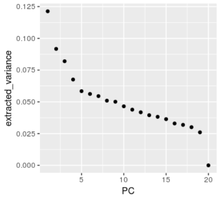

```r
ggplot( pca_PCs , aes( x=PC_1 , y=PC_2 ) ) + geom_point()
ggplot( pca_PCs , aes( x=PC_1 , y=PC_3 ) ) + geom_point()
ggplot( pca_PCs , aes( x=PC_2 , y=PC_3 ) ) + geom_point()
```

Recall from the lecture, the way the population structure is shaped by evolution. Perhaps you can concieve an evolutionary hypothesis that is consistent with the subpopulation structure the PCA reveals. This is how it looked when I tried it on some test data.

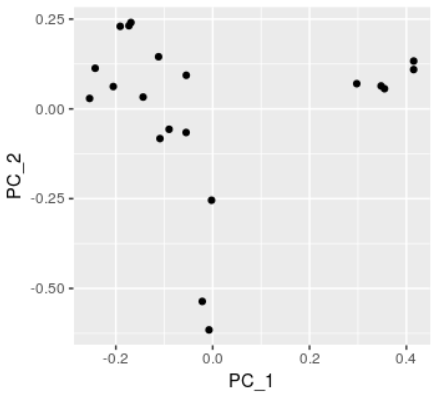

# Merging metadata

One of the most common challenges in informatics is merging data from different tables together. We have a table of information about each sample, for instance, but this isn’t useful unless we can relate it to the SNP data.

But merging can be pretty confusing, so let’s start with a simple example. Consider these two data.tables:

```r
beatles_dates <- data.table(
  event = c("born","died","born","died","born","died","born","died"),
  date = c(1940,1980,1942,NA,1940,NA,1943,2001),
  name = c("john","john","paul","paul","ringo","ringo","george","george")
)

beatles_instruments <- data.table(
  name = c("john","paul","ringo","george"),
  instrument = c("guitar","bass","drums","guitar")
)

beatles_dates
beatles_instruments
```

We might want to merge these together to get one data.table that lists the dates for each Beatles’ life, along with the instruments they played.

The key to understanding merges is to think of one table being used to SELECT rows from the other. In this case, we want each row of `beatles_dates` to SELECT a single row of `beatles_instruments`. And how does it select a row? It chooses one based on the column “name”, which exists in both tables.

To establish which table is doing the SELECTing and which is being SELECTed from, we just put the SELECTing table in the SELECT field. In this case, `beatles_instruments[ beatles_dates ]`.

And we also have to supply a column to merge on, which we do with the `on=` argument. `on=` takes a list of column names (it’s possible to merge on multiple columns but we will just use one today).

```r
beatles_instruments[ beatles_dates , on=.(name) ]
```

That does what we want—the information from one table is now connected to the other. Merging gets complicated fast, for example when the selecting table matches multiple rows. Or when we want to select columns that don’t match a number exactly, but instead we want to do something like “select the row with the closest value below”. For instance, we could ask who was pope when each of the beatles was born or died …

```r
popes <- data.table(
  pope=c("Francis","BenedictXVI","JohnPaulII","PaulVI","JohnXXIII","PiusXII"),
  date=c(2013,2005,1978,1963,1958,1939)
)
#so we will join this ...
popes
# ... to this
beatles_dates

#use roll=TRUE to request the select using the nearest date below
popes[ beatles_dates , on=.(date) , roll=TRUE ]
```

Tricks like this are incredibly important in bioinformatics when, for instance, we have a list of genomic positions, and we want to find the nearest genes.

Right now, we’ll use a merge to join some sample meta-data onto our PCA. For teaching purposes, this meta-data has been modified a bit from the real records.

```r
#map some metadata against that
  #load the metadata
#barley_sample_metadata <- fread("raw_data/barley_panel_sample_metadata.csv")
barley_sample_metadata <- fread("raw_data/barley_panel_sample_metadata.csv")

#have a look at what extra data on these samples we have
barley_sample_metadata

#b[ , sample := sub(".*_","Sample_",accession_id) ]
#b[ , t := (sample %in% barley_sample_metadata$sample) ]
#b[duplicated(sample)]
#setorder(b,-t)


#merge it with the PCA data, or in other words, let each `sample` entry of the PCA data frame select one row from the metadata
pca_and_metadata <-  barley_sample_metadata[ pca_PCs , on=.(sample) ]

#look at the merged result
pca_and_metadata
```

We can now look at our PCAs again and get a feel for the dataset. Are the phenotypes evenly distributed across genetic groups? What are the primary determinants of population structure?

```r
#play with me!!!
ggplot( pca_and_metadata , aes( x=PC_1 , y=PC_2 , colour=bridge_region ) ) + geom_point()
ggplot( pca_and_metadata , aes( x=PC_1 , y=PC_2 , colour=annual_growth_habit ) ) + geom_point()
ggplot( pca_and_metadata , aes( x=PC_1 , y=PC_2 , colour=row_type ) ) + geom_point()
```

As an example, I got this result from the trial data.

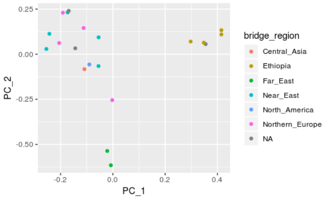

# Running association tests

To run a test between genotypes (SNP states) and phenotypes, we need genotype data (what we stored in the data.table `vcf`) and phenotype data (stored in `pca_and_metadata`). That sounds like a job for the merge function.

```r
#First we'll cut down out variant call table to include only the relevant columns
vcf_gwas_data <- vcf[, .( snp_id , chr , pos , sample , genotype ) ]

#then, merge the information by sample
gwas_info <- pca_and_metadata[ vcf_gwas_data , on=.(sample) ]
#look and understand what information we have
gwas_info
```

Since we’re using a linear model as our association test, we need the predicted variable to be a number. I this case, we will test whether a SNP can predict whether the row-type of a particular individual is 6-rowed. So we will score all the samples where the row_type==“6-rowed” with a 1, and all the others with a 0.

```r
gwas_info[ , row_class := integer() ] #create a new column with type "integer"
gwas_info[ row_type=="6-rowed" , row_class := 1 ]
gwas_info[ row_type!="6-rowed" , row_class := 0 ]
```

Since we have hundreds of SNPs, we’ll run the test on each of them. But to understand the concept, let’s just choose one SNP first and explore that.

```r
#show the principle on one example
test_snp <- unique(gwas_info$snp_id)[1]
gwas_test <- gwas_info[ snp_id==test_snp ]

#look at the SNP we're working with
gwas_test
```

We’re testing for an association between the genotype, and the phenotype (row_class, where 0=“2-rowed” and 1=“6-rowed”). So let’s just look at those columns and see if it looks to us like they are associated:

```r
gwas_test[ , .( genotype , row_class ) ]
```

As a test, ask yourself: What would it look like if they *were* strongly associated?

We can run a linear model on this data to get a p-value for the hypothesis that there is a linear association between genotype and phenotype. The `lm` function needs two arguments. The data.table to get data from, and the model you’re testing, given as a *formula* object. These have the form `VARIABLE_A ~ VARIABLE_B + VARIABLE_C`, which you can read as “VARIABLE_A is predicted by VARIABLE_B and VARIABLE_C”.

```r
fit_SNP <- lm( data=gwas_test , formula = row_class ~ genotype )
summary(fit_SNP)
```

In the summary you get will contain lots of useful information about the linear model, and look something like this:

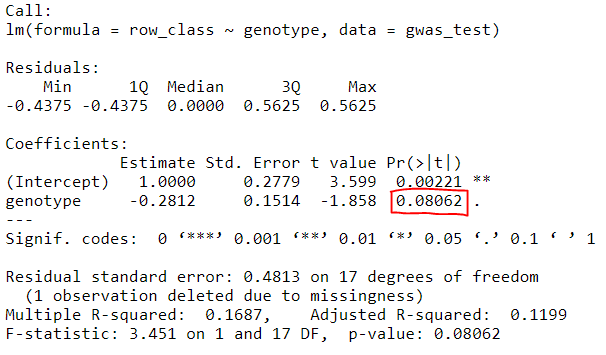

The p-value that tests the influence of the genotype is given in the “Coefficients:” table, in the “genotype” row, in the “Pr(>|t|)” column (red box). The p-value refers to the null hypothesis that the genotype has no effect on the phenotype. As expected, there is not strong evidence for any association in the case I tested above. Which is exactly what you’d expect from a randomly-chosen SNP.

Even if we HAD seen an association, though, recall from the lecture that we can be fooled whenever we look at a single SNP site, because we can’t tell whether the allele at the SNP is truly linked to the phenotype, or whether it is simply an allele that commonly occurs among a sub-population that *all* posess the phenotype.

To control for this effect, we should allow population structure to contribute to predicting the phenotype, and we do this by adding the PCs to the linear model. We can demonstrate this afain with just this one SNP.

to test your understanding, consider this PCA again, and ask yourself:

```
+ Do either of these summaries of population structure (PC_1 or PC_2) seem to help predict the phenotype (row colour)?
+ What would you expect to see on a PCA plot if PC_1 was the major determinant of row type?
```

```r
ggplot( gwas_test , aes( x=PC_1 , y=PC_2 , colour=as.factor(row_class) ) ) + geom_point()
```

Let’s control for population structure by allowing the first five PCs to contribute to the model, and then ask once more what the p-value is for the hypothesis that genotype doesn’t affect phenotype.

```r
lm( data=gwas_test , formula=row_class~genotype+PC_1+PC_2+PC_3+PC_4+PC_5 ) %>% summary
```

When I ran this with test data, I got a p-value of 0.246—so still not a significant correlation.

These commands will run that linear model at *every single SNP* and give back a results table with the p-values as a column. The last line adds a column with p-values scaled in a conventional way. Basically, -log10 p-values are easier to look at.

```r
gwas_results <- gwas_info[ ,  { #p-value testing the null hypothesis that the coefficient is in fact zero, using a t-test
    out <- summary(lm( data=.SD , formula=row_class~genotype+PC_1+PC_2+PC_3+PC_4+PC_5 ))$coefficients['genotype',]
    .( coefficient=out[1], std_err_coeff=out[2], t=out[3], p_value=out[4] )
  } , by=.(snp_id,pos,chr) ]
#add a scaled p-value
gwas_results[ , neg_log10_p_value := -log10(p_value)]
```

The most typical way to visually represent the results of a GWAS is to put the position of the SNP on one axis, and the -log10(p-value) on the Y-axis. This is called a Manhattan Plot.

```r
#manhattan plot
ggplot(gwas_results,aes(x=pos,y=neg_log10_p_value)) + geom_point(size=.2)
```

So each dot here is a SNP, and some show stronger evidence of association than others. But what would count as a “significant” level of association?

A naive approach would be to use the standard approach of accepting p-values below 0.05. We can mark this on the plot using a horizontal bar, which is provided by geom_hline().

```r
#We are showing -log10(p-value), so we need to draw the line at -log10(0.05)
unadjusted_pvalue_cutoff <- -log10(0.05)

#Plot including a line
ggplot( gwas_results , aes(x=pos,y=neg_log10_p_value) ) + geom_point( size=.2)  + geom_hline( yintercept=unadjusted_pvalue_cutoff )
```

This shows a suspiciously high number of significant associations. And of course it does, a 0.05 p-value means approximately 1 out of every 20 false associations will still reach the threshold, and we are testing hundreds!

The Bonferroni correction is one way of setting a more sensible cutoff. We simply divide the cutoff value by the number of tests we did (i.e., the number of SNPs, since we ran the linear model once for each SNP)

```r
bonferroni_adjusted_pvalue_cutoff <- -log10( 0.05 / nrow(gwas_results) )

#make the bonferroni-corrected cutoff red with the `colour="red"` argument
ggplot(gwas_results,aes(x=pos,y=neg_log10_p_value)) + geom_point(size=.2) + geom_hline(yintercept=unadjusted_pvalue_cutoff) + geom_hline( yintercept=bonferroni_adjusted_pvalue_cutoff , colour="red" )
```

My result looked like this:

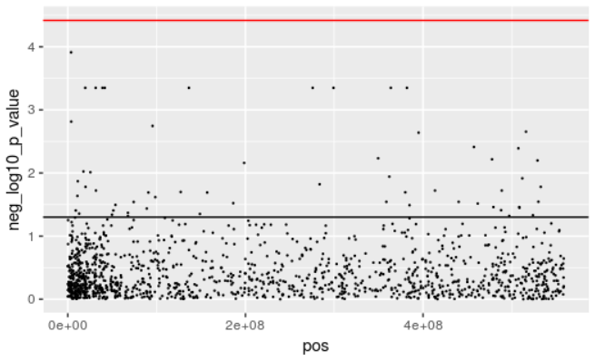

Now, we have run a GWAS across 20 samples. So it’s not really surprising if we have no statistically “significant” associations (though, who knows? Perhaps in your own datasets you will find some.) This XKCD cartoon summarises it nicely …

[figure not shown]

In a more expansive study that found convincing associations, a good next step would be to investigate what genes or relevant genetic features occur in the vicinity of the trait-associated SNPs. A researcher might now go on to investigate the functions of genes found near associated markers, checking whether they might have functions that relate to the phenotype and so on.

But for this course, we are at the end of the required analysis. But there is still plenty of exploration that could be done with the data here, and if you thought of any ways to explore the data that we didn’t cover, perhaps your skillset is now broad enough to dig deeper yourself.

In the final lecture we will outline how to repeat this analysis on your own data, and how it can be written into a scientific report for the assignment. Congratulations!

# Exercises

- Try merging the Beatles datasets again, but add another row to the ‘beatles_dates’ data.table that doesn’t match any names in ‘beatles_instruments’. What happens?
- Try merging the Beatles datasets again, but add some more rows to ‘beatles_instruments’ to show that john also played the harmonica. Now, the name “john” in ‘beatles_dates’ will match two rows. What happens in the merge?
- Open and understand the contents of the `read_annotation()` function. You may have top use Google or manual pages to look up the data.table special variable “.SD”.
- Theoretically, if the linear model we used was appropriate for the data, then about 5% of the p-values in ‘gwas_results’ should be below 0.05. Write some commands to check this assumption.